# DHiam_BikeShare_Project 2

**Set Working Directory and Load files**

```
## [1] "C:/Users/e5104965/udacity-git-course/Bike-Share"
```

```
## [1] "chicago.csv"       "new-york-city.csv" "washington.csv"
```

**Upload Packages required**

**Bind all 3 datasets into single dataset to get results for overall findings**

```
## Warning in bind_rows_(x, .id): binding character and factor vector, coercing
## into character vector

## Warning in bind_rows_(x, .id): binding character and factor vector, coercing
## into character vector
```

```
## Warning in bind_rows_(x, .id): Unequal factor levels: coercing to character
```

[output not shown]

```
## [1] 900000      9
```

**NOTE** Each dataset has 300000 observations and 9 variable expcept for Washington who does not have gender or Birth year data and these are allocated NA. While there are warnings they are acceptable.

**Popular times of travel (i.e., occurs most often in the start time)**

*QUESTION ONE: What is the most common month?*

| month | frequency |
| --- | --- |
| January | 83744 |
| February | 105730 |
| March | 103666 |
| April | 172455 |
| May | 191963 |
| June | 242442 |

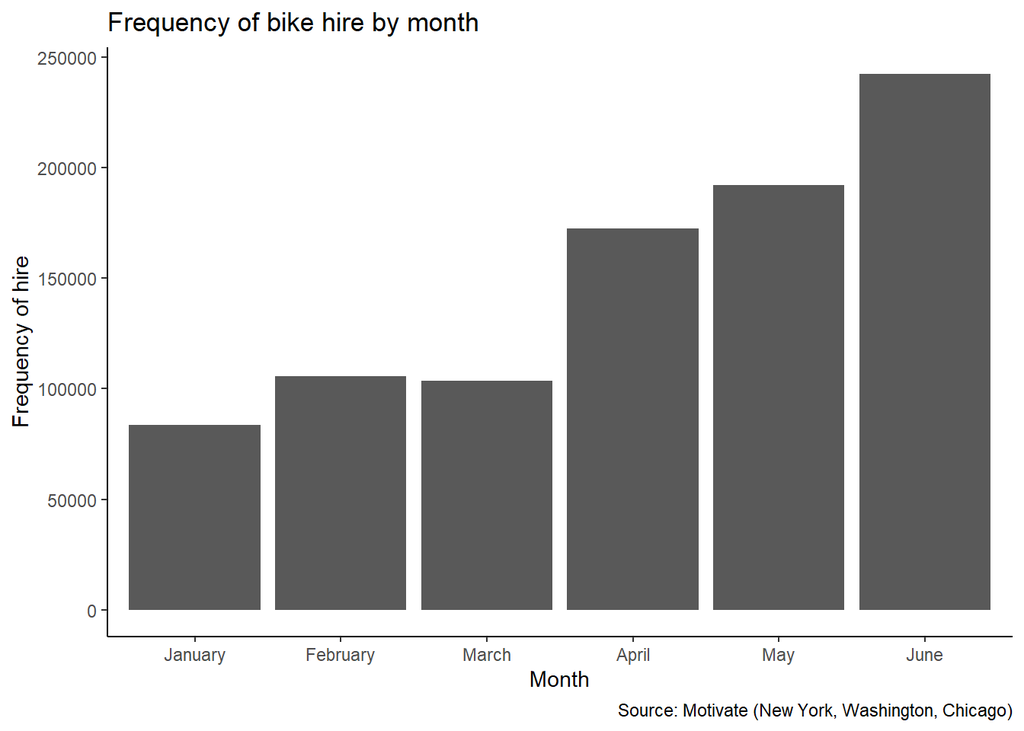

**Answer: According to the graph and the numeric summary June is the most common month for bike hires.**

*What is the most common day of the week*

```r
Bind_ALL$day <-wday(dmy_hm(Bind_ALL$Start.Time), label=TRUE, abbr = FALSE)
```

```r
library(knitr)
day <- Bind_ALL %>%
  group_by(day) %>%
  summarise(frequency = n())
kable(day)
```

| day | frequency |
| --- | --- |
| Sunday | 114502 |
| Monday | 126734 |
| Tuesday | 134183 |
| Wednesday | 142773 |
| Thursday | 134538 |
| Friday | 131866 |
| Saturday | 115404 |

Visualise Q2

```r
Graph=as.data.frame(day)
dim(day)
```

```
## [1] 7 2
```

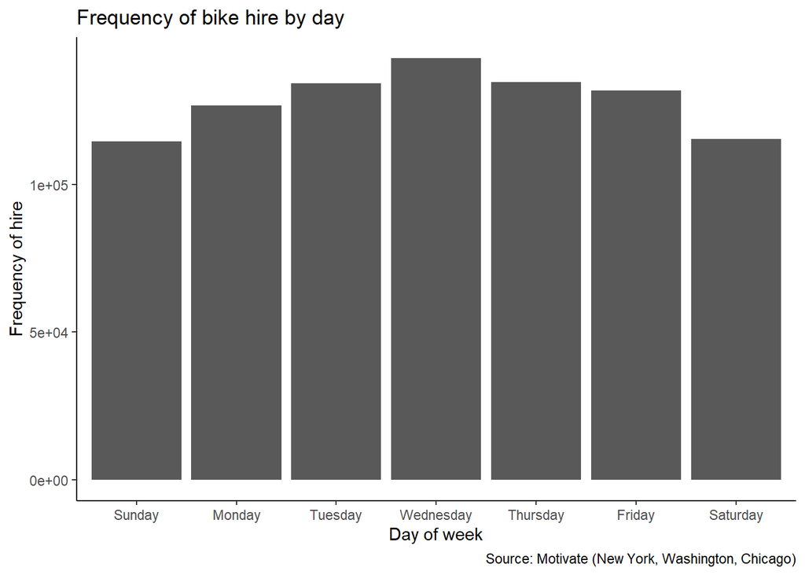

```r
ggplot(aes(x=day, y=frequency), data=day) +
  geom_col()+
  theme_classic()+
  labs(y="Frequency of hire",
       x="Day of week",
       title="Frequency of bike hire by day",
       caption = "Source: Motivate (New York, Washington, Chicago)")
```

*QUESTION 3: What is the most common hour of day?*

```r
Bind_ALL$hour <- hour(dmy_hm(Bind_ALL$Start.Time))
```

```r
hour <- Bind_ALL %>%
  group_by(hour) %>%
  summarise(frequency = n())
kable(hour)
```

| hour | frequency |
| --- | --- |
| 0 | 4740 |
| 1 | 14211 |
| 2 | 12910 |
| 3 | 13108 |
| 4 | 16170 |
| 5 | 27165 |
| 6 | 38245 |
| 7 | 61003 |
| 8 | 81734 |
| 9 | 53215 |
| 10 | 41401 |
| 11 | 45799 |
| 12 | 52109 |
| 13 | 40487 |
| 14 | 41381 |
| 15 | 45756 |
| 16 | 58937 |
| 17 | 79373 |
| 18 | 62237 |
| 19 | 41450 |
| 20 | 27341 |
| 21 | 19142 |
| 22 | 13650 |
| 23 | 8436 |

Visualise Q3

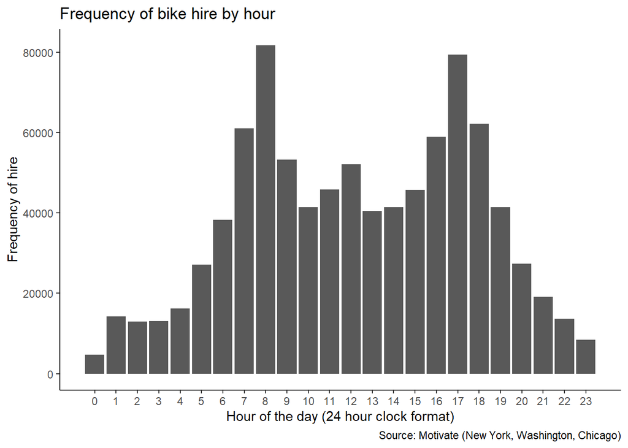

```r
Graph=as.data.frame(hour)
ggplot(aes(x=hour, y=frequency), data=hour) +
  geom_col()+
  theme_classic()+
  scale_x_continuous(breaks = 0:23)+
  labs(y="Frequency of hire",
       x="Hour of the day (24 hour clock format)",
       title="Frequency of bike hire by hour",
       caption = "Source: Motivate (New York, Washington, Chicago)")
```

**According to the graph and numeric summary (labelled hour) 8am is the most common hour for bike hires.**